# Summarizing data

Johanna Jantzen

November 18, 2020

## Summary of Data

In this document, I summmarize the data available from the CABO project.

I am using Fulcrum metadata downloaded on November 17, 2020 using the following link.

```r
#read in metadata object
#metadata_fulcrum <- read.csv("https://web.fulcrumapp.com/shares/5c5290b884ab3734.csv", stringsAsFactors = FALSE) # Fulcrum data share link (first edit column names for reading)
metadata_fulcrum <- read.csv("./data/exported_raw/leaf_spectra.csv", stringsAsFactors = FALSE)
```

The spectral data available was compiled by Shan Kothari (received October 21, 2020).

```r
#this is the preliminary version (cleaned by Shan)
spectral_data <- readRDS("./data/all_spectra.rds")

#get the metadata from the spectra object
metadata_Shan <- meta(spectral_data)
```

I will first reduce the metadata to those samples with spectra in Shan's spectral data file. Those samples missing from the spectral file are saved in a list.

```r
#keep only the metadata from fulcrum for samples in Shan's spectral file
matched_meta <- metadata_fulcrum[which(metadata_fulcrum$sample_id %in% metadata_Shan$sample_id),]
nrow(matched_meta)
```

```
## [1] 2060
```

```r
#those spectra without metadata
missing_spectra <- metadata_fulcrum[-which(metadata_fulcrum$sample_id %in% metadata_Shan$sample_id),]
nrow(missing_spectra)
```

```
## [1] 36
```

```r
#there are some submitted samples without spectra (only 19?)
unique(missing_spectra$status)
```

```
## [1] "deleted"   "rejected"  "submitted" "verified"  "pending"
```

```r
#missing_spectra[which(missing_spectra$status == "submitted"),]

#those samples without spectra
missing_metadata <- metadata_Shan[-which(metadata_Shan$sample_id %in% metadata_fulcrum$sample_id),]
nrow(missing_metadata)
```

```
## [1] 200
```

```r
#Exclude spectra from Dessain because no metadata and because they used a different instrument to measure spectra
unique(missing_metadata$project)
```

```
## [1] "2017-Dessain-MSc"
```

```r
#save missing data objects
saveRDS(missing_spectra, "./data/tidy/fulcrum_missing_spectra.rds")
saveRDS(missing_metadata, "./data/tidy/spectra_missing_fulcrum.rds")
```

With the matched dataset, I merge the leaf spectra (only those whose status is submitted), bulk sample, and plant dataframes. I check for duplicate sample IDs and errors in matching plant ID to sample ID.

```r
#make sure no missing IDs for metadata
still_missing_species_IDS <- matched_meta$sample_id[which(is.na(matched_meta$species))]

#make sure only submitted samples - remove statuses
#nrow(matched_meta)
status_matched_meta <- matched_meta[which(matched_meta$status == "submitted"),]
#nrow(status_matched_meta)

#need to match plant ID with sample ID because taxonomy of leaf spectra metadata is not updated (as a rule)

#read plants data
plants <- read.csv("./data/exported_raw/plants.csv", stringsAsFactors = FALSE)

#read bulk sample data to merge plants and leaf spectra data
bulk_samples <- read.csv("./data/exported_raw/bulk_leaf_samples.csv", stringsAsFactors = FALSE)

#retrieve plant ids for samples in leaf spectra (separately)
plant_id_for_spectra <- bulk_samples[which(bulk_samples$sample_id %in% status_matched_meta$sample_id),]
nrow(plant_id_for_spectra) #2051
```

```
## [1] 2051
```

```r
length(status_matched_meta$sample_id) #2052 - one more sample than have plant ids
```

```
## [1] 2052
```

```r
#there is one sample that has a unqiue sample_id but no plant_id

#checking for duplicate sample_ids
unique(status_matched_meta$sample_id %in% bulk_samples$sample_id)
```

```
## [1] TRUE
```

```r
status_matched_meta[which(duplicated(status_matched_meta$sample_id) == TRUE),c(9,10,12,13,19,20,21,22)] #sample_id = 44682364
```

```
##         status              project latitude longitude site_id sample_id
## 1481 submitted 2019-Crofts-PhD-UdeS 45.46135 -71.06926 MtMeg-1  44682364
##              scientific_name date_measured
## 1481 Acer saccharum Marshall    2019-07-22
```

```r
#status_matched_meta[which("44682364"%in% status_matched_meta$sample_id),]
bulk_samples[which(bulk_samples$sample_id == "44682364"),c(9,10,12,13,21,22,23,26,30)] #plant_id = 44226204; sample_id = 44682364
```

```
##       status              project latitude longitude         scientific_name
## 1525 pending 2019-Crofts-PhD-UdeS    45.48 -71.21082 Acer saccharum Marshall
##      site_id plant_id date_sampled sample_id
## 1525 MtMeg-1 44226204   2019-07-22  44682364
```

```r
status_matched_meta[which(status_matched_meta$sample_id == "44682364"),c(4,9,10,12,13,19,20,21,22,23,26,30)] #two samples with different gps but same sample_id
```

```
##                                created_by    status              project
## 1476 madeleine.trickey-masse@umontreal.ca submitted 2019-Crofts-PhD-UdeS
## 1481           isabelle_gareau@hotmail.fr submitted 2019-Crofts-PhD-UdeS
##      latitude longitude site_id sample_id         scientific_name date_measured
## 1476 45.47996 -71.21087 MtMeg-1  44682364 Acer saccharum Marshall    2019-07-22
## 1481 45.46135 -71.06926 MtMeg-1  44682364 Acer saccharum Marshall    2019-07-22
##                   measured_by event_remarks manufacturer_short_name
## 1476 Madeleine Trickey-MassÃ©                                   SVC
## 1481 Madeleine Trickey-MassÃ©                                   SVC
```

```r
#bulk_samples[which(bulk_samples$sample_id == "44682364"),] #two samples with different gps but same sample_id, and one plant id (for the sample id in bulk samples)
nrow(status_matched_meta) #2052
```

```
## [1] 2052
```

```r
#remove sample without plant id
status_matched_meta <- status_matched_meta[-which(status_matched_meta$sample_id == "44682364"),]
nrow(status_matched_meta) #2050
```

```
## [1] 2050
```

```r
#there is no missing plant id info in bulk samples for spectra after removing the duplicate sample ID
missing_plant_id_for_spectra <- status_matched_meta$sample_id[-which(status_matched_meta$sample_id %in% bulk_samples$sample_id)]

#get species IDs for plant ids in spectra
species_ids_for_spectra <- plants[which(plants$plant_id %in% plant_id_for_spectra$plant_id),]
nrow(species_ids_for_spectra)
```

```
## [1] 1804
```

```r
# #quite a few samples have duplicate plant_ids (as expected)
# plant_id_for_spectra[which(duplicated(plant_id_for_spectra$plant_id) == TRUE),]

#make new dataframe for matching species ids and plant_ids

#first change name of columns to match origin
colnames(status_matched_meta) <- paste0("LS.", names(status_matched_meta))
colnames(bulk_samples) <- paste0("BS.", names(bulk_samples))
colnames(plants) <- paste0("PL.", names(plants))
#colnames(plants)

#first join bulk samples by sample id
species_reconc <- merge(status_matched_meta, bulk_samples, by.x = "LS.sample_id", by.y = "BS.sample_id", all.x = TRUE)
nrow(species_reconc)
```

```
## [1] 2050
```

```r
length(unique(species_reconc$BS.plant_id)) #1804
```

```
## [1] 1804
```

```r
length(unique(species_reconc$LS.sample_id)) #2050
```

```
## [1] 2050
```

```r
#species_reconc$LS.sample_id

#then add plant ids
species_reconc <- merge(species_reconc, plants, by.x = "BS.plant_id", by.y = "PL.plant_id", all.x = TRUE) #those colnames without a specifier are from the plants dataframe
nrow(species_reconc)
```

```
## [1] 2051
```

```r
#why does this step add a sample
length(unique(species_reconc$BS.plant_id)) #1804
```

```
## [1] 1804
```

```r
length(unique(species_reconc$LS.sample_id)) #2050
```

```
## [1] 2050
```

```r
#didn't add the sample with duplicate sample_id above
nrow(species_reconc[which(species_reconc$LS.sample_id == "44682364"),])
```

```
## [1] 0
```

```r
nrow(species_reconc[which(species_reconc$BS.plant_id == "44226204"),])
```

```
## [1] 0
```

```r
#check for duplicate sample_ids
#species_reconc[which(species_reconc$LS.sample_id[which(duplicated(species_reconc$LS.sample_id) == TRUE)][1] %in% status_matched_meta$LS.sample_id),]

#duplicated sample id
species_reconc$LS.sample_id[which(duplicated(species_reconc$LS.sample_id) == TRUE)][1] #41295307
```

```
## [1] 41295307
```

```r
#41295307 sample id
#plant id 40175425
species_reconc[which(species_reconc$LS.sample_id == "41295307"),c(1,2,11,12,21,22,23,24,78,83,84,86,87,95,96,99,129,134,135,137,138,142,158,163,164,176)] #different gps for plants and plant created by different people
```

```
##     BS.plant_id LS.sample_id LS.status              LS.project       LS.site_id
## 966    40175425     41295307 submitted 2019-Blanchard-MSc-UdeM IdB_ile_ste_marg
## 967    40175425     41295307 submitted 2019-Blanchard-MSc-UdeM IdB_ile_ste_marg
##        LS.scientific_name LS.date_measured     LS.measured_by
## 966 Acer negundo Linnaeus       2019-06-13 Florence Blanchard
## 967 Acer negundo Linnaeus       2019-06-13 Florence Blanchard
##                      BS.created_by BS.status              BS.project
## 966 antoine.mathieu.1@umontreal.ca   pending 2019-Blanchard-MSc-UdeM
## 967 antoine.mathieu.1@umontreal.ca   pending 2019-Blanchard-MSc-UdeM
##     BS.latitude BS.longitude    BS.scientific_name       BS.site_id
## 966    45.59091     -73.4725 Acer negundo Linnaeus IdB_ile_ste_marg
## 967    45.59091     -73.4725 Acer negundo Linnaeus IdB_ile_ste_marg
##     BS.date_sampled                        PL.created_by PL.status
## 966      2019-06-13 madeleine.trickey-masse@umontreal.ca   pending
## 967      2019-06-13       antoine.mathieu.1@umontreal.ca submitted
##                  PL.project PL.latitude PL.longitude       PL.site_id
## 966       2019-CABO-General    45.59506    -73.48136  IdB_ile_charron
## 967 2019-Blanchard-MSc-UdeM    45.59084    -73.47266 IdB_ile_ste_marg
##                                                                                                  PL.plant_remarks
## 966 Not used for spectra and not tagged. Buckthorn control might be done in this area by the park administration.
## 967
##     PL.latitude.1 PL.longitude.1          PL.scientific_name
## 966      45.59506      -73.48136 Rhamnus cathartica Linnaeus
## 967      45.59084      -73.47266       Acer negundo Linnaeus
```

```r
species_reconc[which(species_reconc$BS.plant_id == "40175425"),c(1,2,11,12,21,22,23,24,78,83,84,86,87,95,96,99,129,134,135,137,138,142,158,163,164,176)] #I think the issue is two different trees entered into plant database with same plant ID and therefore linked to sample ID because single sample in leaf spectra
```

```
##     BS.plant_id LS.sample_id LS.status              LS.project       LS.site_id
## 966    40175425     41295307 submitted 2019-Blanchard-MSc-UdeM IdB_ile_ste_marg
## 967    40175425     41295307 submitted 2019-Blanchard-MSc-UdeM IdB_ile_ste_marg
##        LS.scientific_name LS.date_measured     LS.measured_by
## 966 Acer negundo Linnaeus       2019-06-13 Florence Blanchard
## 967 Acer negundo Linnaeus       2019-06-13 Florence Blanchard
##                      BS.created_by BS.status              BS.project
## 966 antoine.mathieu.1@umontreal.ca   pending 2019-Blanchard-MSc-UdeM
## 967 antoine.mathieu.1@umontreal.ca   pending 2019-Blanchard-MSc-UdeM
##     BS.latitude BS.longitude    BS.scientific_name       BS.site_id
## 966    45.59091     -73.4725 Acer negundo Linnaeus IdB_ile_ste_marg
## 967    45.59091     -73.4725 Acer negundo Linnaeus IdB_ile_ste_marg
##     BS.date_sampled                        PL.created_by PL.status
## 966      2019-06-13 madeleine.trickey-masse@umontreal.ca   pending
## 967      2019-06-13       antoine.mathieu.1@umontreal.ca submitted
##                  PL.project PL.latitude PL.longitude       PL.site_id
## 966       2019-CABO-General    45.59506    -73.48136  IdB_ile_charron
## 967 2019-Blanchard-MSc-UdeM    45.59084    -73.47266 IdB_ile_ste_marg
##                                                                                                  PL.plant_remarks
## 966 Not used for spectra and not tagged. Buckthorn control might be done in this area by the park administration.
## 967
##     PL.latitude.1 PL.longitude.1          PL.scientific_name
## 966      45.59506      -73.48136 Rhamnus cathartica Linnaeus
## 967      45.59084      -73.47266       Acer negundo Linnaeus
```

```r
status_matched_meta[which(status_matched_meta$LS.sample_id == "41295307"),c(4,9,10,12,13,19,20,21,22,23)]
```

```
##                        LS.created_by LS.status              LS.project
## 1024 florence.blanchard@umontreal.ca submitted 2019-Blanchard-MSc-UdeM
##      LS.latitude LS.longitude       LS.site_id LS.sample_id
## 1024          NA           NA IdB_ile_ste_marg     41295307
##         LS.scientific_name LS.date_measured     LS.measured_by
## 1024 Acer negundo Linnaeus       2019-06-13 Florence Blanchard
```

```r
plants[which(plants$PL.plant_id == "40175425"),c(4,9,10,12,13,17,22,39,40,52,54)] #two plants with same plant ID in plants dataframe
```

```
##                             PL.created_by PL.status              PL.project
## 1235 madeleine.trickey-masse@umontreal.ca   pending       2019-CABO-General
## 1260       antoine.mathieu.1@umontreal.ca submitted 2019-Blanchard-MSc-UdeM
##      PL.latitude PL.longitude       PL.site_id PL.plant_id PL.latitude.1
## 1235    45.59506    -73.48136  IdB_ile_charron    40175425      45.59506
## 1260    45.59084    -73.47266 IdB_ile_ste_marg    40175425      45.59084
##      PL.longitude.1          PL.scientific_name         PL.identified_by
## 1235      -73.48136 Rhamnus cathartica Linnaeus Madeleine Trickey-MassÃ©
## 1260      -73.47266       Acer negundo Linnaeus          Antoine Mathieu
```

```r
#remove two samples with different trees (for now) - can revisit if plant is fixed
species_reconc <- species_reconc[-which(species_reconc$BS.plant_id == "40175425"),]
nrow(species_reconc)
```

```
## [1] 2049
```

```r
#check a plant id example
species_reconc[which(species_reconc$BS.plant_id == "8553450"),c(1,2,22,23,84,86,87,95,176)]
```

```
##   BS.plant_id LS.sample_id          LS.scientific_name LS.date_measured
## 1     8553450      9332593 Betula populifolia Marshall       2018-06-08
## 2     8553450     19874249 Betula populifolia Marshall       2018-10-08
## 3     8553450     10454172 Betula populifolia Marshall       2018-06-21
## 4     8553450     18663077 Betula populifolia Marshall       2018-09-24
## 5     8553450     21854888 Betula populifolia Marshall       2018-10-08
## 6     8553450     17537834 Betula populifolia Marshall       2018-09-11
## 7     8553450     15293031 Betula populifolia Marshall       2018-08-16
## 8     8553450     12875138 Betula populifolia Marshall       2018-07-19
##                     BS.project BS.latitude BS.longitude
## 1 2018-BeauchampRioux-MSc-UdeM    45.54396    -73.33839
## 2 2018-BeauchampRioux-MSc-UdeM    45.48583    -73.57580
## 3 2018-BeauchampRioux-MSc-UdeM    45.53956    -73.35586
## 4 2018-BeauchampRioux-MSc-UdeM    45.48590    -73.57582
## 5 2018-BeauchampRioux-MSc-UdeM    45.48583    -73.57580
## 6 2018-BeauchampRioux-MSc-UdeM          NA           NA
## 7 2018-BeauchampRioux-MSc-UdeM          NA           NA
## 8 2018-BeauchampRioux-MSc-UdeM          NA           NA
##            BS.scientific_name          PL.scientific_name
## 1 Betula populifolia Marshall Betula populifolia Marshall
## 2 Betula populifolia Marshall Betula populifolia Marshall
## 3 Betula populifolia Marshall Betula populifolia Marshall
## 4 Betula populifolia Marshall Betula populifolia Marshall
## 5 Betula populifolia Marshall Betula populifolia Marshall
## 6 Betula populifolia Marshall Betula populifolia Marshall
## 7 Betula populifolia Marshall Betula populifolia Marshall
## 8 Betula populifolia Marshall Betula populifolia Marshall
```

```r
unique(species_reconc$BS.plant_id[which(species_reconc$PL.scientific_name == "Betula populifolia Marshall")])
```

```
##  [1]  8553450  8553606  8553762  8553879  8554325  8554549  8554747  8555047
##  [9]  8555416  9256758  9256838  9257389  9257450  9257626  9257814  9259254
## [17]  9259431  9259629  9259925  9260050  9260295  9260318  9261228  9856632
## [25]  9856711  9856938  9857445  9857644  9857701  9857951  9858107  9858309
## [33]  9858517 11158489 11158574 11158654 11158783 11159020 11159096 11159261
## [41] 11159359 11159540 11159561 11667258 11667532 11667690 11667896 11747375
## [49] 12015467 12015546 12015691 12016026 12016170 12016522 12017210 12020358
## [57] 12020619 12098070 12797425 12797765 12799527 12800923 12801051 12801174
## [65] 12801241 12801517 13988753 13988860 44237164 44237429 44336271 44336728
## [73] 44669304 44669866 44669924 44682746 44684446 44685658
```

```r
nrow(species_reconc)
```

```
## [1] 2049
```

```r
#save as reference point
saveRDS(species_reconc, "./data/tidy/species_reconcile_plants.rds")
```

Of 2052 samples of status "submitted", there are 2051 with plant IDs (this is resolved after removing duplicate samples). There are two samples in the leaf spectra dataframe with duplicate sample IDs. These were removed here leaving 2050 samples. After merging the dataframes, two different plants (different species names, different locations) with the same plant ID were identified. These were also removed, leaving 2049 samples.

Next, the data are tidied to get dates and names into separate fields. The **correct** species names are in the plants database, so in the PL.scientific_name column.

```r
#first, get the field which has correct species names

#make dataframes with structure: sample_ID, proj_name, sp_name.lf, sp_name.pl, date, siteID.ls, plant_id,
#colnames(species_reconc)
small_matched_meta <- species_reconc %>%
  select(BS.plant_id, LS.sample_id, LS.project, LS.latitude, LS.longitude, LS.site_id, LS.scientific_name, LS.date_measured, LS.gps_altitude, BS.project, BS.latitude, BS.longitude, BS.scientific_name, BS.site_id, BS.plant_remarks, BS.date_sampled, BS.time_sampled, PL.project, PL.latitude, PL.longitude, PL.site, PL.plot, PL.site_id, PL.plot_id, PL.plant_remarks, PL.vascan_taxon, PL.scientific_name, PL.identification_qualifier, PL.altitude)

str(small_matched_meta)
```

```
## 'data.frame':    2049 obs. of  29 variables:
##  $ BS.plant_id                : int  8553450 8553450 8553450 8553450 8553450 8553450 8553450 8553450 8553606 8553606 ...
##  $ LS.sample_id               : int  9332593 19874249 10454172 18663077 21854888 17537834 15293031 12875138 10453164 17536826 ...
##  $ LS.project                 : chr  "2018-BeauchampRioux-MSc-UdeM" "2018-BeauchampRioux-MSc-UdeM" "2018-BeauchampRioux-MSc-UdeM" "2018-BeauchampRioux-MSc-UdeM" ...
##  $ LS.latitude                : num  45.6 45.5 0 45.5 45.5 ...
##  $ LS.longitude               : num  -73.5 -73.6 0 -73.6 -73.6 ...
##  $ LS.site_id                 : chr  "CF_MSB" "CF_MSB" "CF_MSB" "CF_MSB" ...
##  $ LS.scientific_name         : chr  "Betula populifolia Marshall" "Betula populifolia Marshall" "Betula populifolia Marshall" "Betula populifolia Marshall" ...
##  $ LS.date_measured           : chr  "2018-06-08" "2018-10-08" "2018-06-21" "2018-09-24" ...
##  $ LS.gps_altitude            : num  NA -13.5 NA -12.1 -13.5 ...
##  $ BS.project                 : chr  "2018-BeauchampRioux-MSc-UdeM" "2018-BeauchampRioux-MSc-UdeM" "2018-BeauchampRioux-MSc-UdeM" "2018-BeauchampRioux-MSc-UdeM" ...
##  $ BS.latitude                : num  45.5 45.5 45.5 45.5 45.5 ...
##  $ BS.longitude               : num  -73.3 -73.6 -73.4 -73.6 -73.6 ...
##  $ BS.scientific_name         : chr  "Betula populifolia Marshall" "Betula populifolia Marshall" "Betula populifolia Marshall" "Betula populifolia Marshall" ...
##  $ BS.site_id                 : chr  "MSB_Chemin" "MSB_Chemin" "MSB_Chemin" "MSB_Chemin" ...
##  $ BS.plant_remarks           : chr  "" "" "" "" ...
##  $ BS.date_sampled            : chr  "2018-06-08" "2018-10-08" "2018-06-21" "2018-09-24" ...
##  $ BS.time_sampled            : chr  "12:24" "12:38" "11:57" "12:12" ...
##  $ PL.project                 : chr  "2018-BeauchampRioux-MSc-UdeM" "2018-BeauchampRioux-MSc-UdeM" "2018-BeauchampRioux-MSc-UdeM" "2018-BeauchampRioux-MSc-UdeM" ...
##  $ PL.latitude                : num  45.5 45.5 45.5 45.5 45.5 ...
##  $ PL.longitude               : num  -73.3 -73.3 -73.3 -73.3 -73.3 ...
##  $ PL.site                    : chr  "c8ce612b-48ff-4423-b201-aa3c9a677458" "c8ce612b-48ff-4423-b201-aa3c9a677458" "c8ce612b-48ff-4423-b201-aa3c9a677458" "c8ce612b-48ff-4423-b201-aa3c9a677458" ...
##  $ PL.plot                    : chr  "" "" "" "" ...
##  $ PL.site_id                 : chr  "MSB_Chemin" "MSB_Chemin" "MSB_Chemin" "MSB_Chemin" ...
##  $ PL.plot_id                 : int  8465014 8465014 8465014 8465014 8465014 8465014 8465014 8465014 8465014 8465014 ...
##  $ PL.plant_remarks           : chr  "" "" "" "" ...
##  $ PL.vascan_taxon            : chr  "f30af9ea-704a-4ea6-ae36-ae7be85d468e" "f30af9ea-704a-4ea6-ae36-ae7be85d468e" "f30af9ea-704a-4ea6-ae36-ae7be85d468e" "f30af9ea-704a-4ea6-ae36-ae7be85d468e" ...
##  $ PL.scientific_name         : chr  "Betula populifolia Marshall" "Betula populifolia Marshall" "Betula populifolia Marshall" "Betula populifolia Marshall" ...
##  $ PL.identification_qualifier: chr  "" "" "" "" ...
##  $ PL.altitude                : num  45.8 45.8 45.8 45.8 45.8 ...
```

```r
#remove samples without corresponding plant in plants database
small_matched_meta <- small_matched_meta[-which(is.na(small_matched_meta$PL.scientific_name)),]

#see which differences there are in species ID in the different datasets
mismatched_names <- data.frame(spectral_name = as.character(), plants_name = as.character(), sample_name = as.character())
for (i in 1:nrow(small_matched_meta)){
  spectral_name <- small_matched_meta$LS.scientific_name[i]
  plants_name <- small_matched_meta$PL.scientific_name[i]
  sample_name <- small_matched_meta$LS.sample_id[i]
  next_one <- data.frame(spectral_name, plants_name, sample_name)
  if (spectral_name != plants_name){
    mismatched_names <- rbind(mismatched_names, next_one)
  }
}

nrow(small_matched_meta)
```

```
## [1] 2047
```

```r
nrow(mismatched_names)
```

```
## [1] 167
```

```r
saveRDS(mismatched_names, "./data/tidy/mismatched_names.rds")
```

There are 167 samples with names that need updating (will update all but those have changes). Spectral dataframe will be updated with the PL.scientific_name column.

```r
# #convert date to ymd from mdy - not necessary for data from metadata as imported here
# small_matched_meta$YMD <- mdy(small_matched_meta$LS.date_measured)

#separate species names into genus, species, authority

#run for metadata species names (from index page)
names_splitting_metadata <- splitting_species_names(small_matched_meta)

# #check for subspecific names through extra columns
# unique(names_splitting_metadata$extra0)#subsp. var.
# unique(names_splitting_metadata$extra1)#subsp. var. spissum rugosa strigosus
# unique(names_splitting_metadata$extra2)#angustifolia vaginatum altissima
# unique(names_splitting_metadata$extra3)#
# unique(names_splitting_metadata$extra4)#subsp.
# unique(names_splitting_metadata$extra5)#australis
# unique(names_splitting_metadata$extra6)#
# unique(names_splitting_metadata$extra7)
# unique(names_splitting_metadata$extra8)
# unique(names_splitting_metadata$extra9)
# unique(names_splitting_metadata$extra10)
# unique(names_splitting_metadata$extra11)

#those with out specific epithets - leave in for now, except that without plant entry
names_splitting_metadata[which(is.na(names_splitting_metadata$extra0)),c(1:3,7,13,27)] #the quercus entries will be just quercus
```

```
##      BS.plant_id LS.sample_id              LS.project        LS.scientific_name
## 1296    42516544     43021621 2019-Blanchard-MSc-UdeM          Quercus Linnaeus
## 1712    44667317     44947679    2019-Crofts-PhD-UdeS Fagus grandifolia Ehrhart
## 1816    45957095     46050997 2019-Blanchard-MSc-UdeM          Quercus Linnaeus
## 1819    45957792     46044059 2019-Blanchard-MSc-UdeM          Quercus Linnaeus
## 1860    46045663     46045661 2019-Blanchard-MSc-UdeM          Quercus Linnaeus
## 1861    46047248     46047245 2019-Blanchard-MSc-UdeM          Quercus Linnaeus
## 1862    46048062     46048059 2019-Blanchard-MSc-UdeM          Quercus Linnaeus
## 1863    46049744     46049737 2019-Blanchard-MSc-UdeM          Quercus Linnaeus
##             BS.scientific_name PL.scientific_name
## 1296          Quercus Linnaeus   Quercus Linnaeus
## 1712 Fagus grandifolia Ehrhart
## 1816          Quercus Linnaeus   Quercus Linnaeus
## 1819          Quercus Linnaeus   Quercus Linnaeus
## 1860          Quercus Linnaeus   Quercus Linnaeus
## 1861          Quercus Linnaeus   Quercus Linnaeus
## 1862          Quercus Linnaeus   Quercus Linnaeus
## 1863          Quercus Linnaeus   Quercus Linnaeus
```

```r
#remove the sample without a name in the plant entry
names_splitting_metadata <- names_splitting_metadata[-which(names_splitting_metadata$BS.plant_id == "44667317"),]

#the original entry for that plant without a name
#plants[which(plants$PL.plant_id == "44667317"),]

#remove specific epithet "Linnaeus" for Quercu ssamples
names_splitting_metadata$specific_epithet[which(names_splitting_metadata$specific_epithet == "Linnaeus")] <- NA

#get rid of extra columns due to subspecific names  (edit as needed)
metadata_with_names <- names_splitting_metadata[,-c(30:40)]

#get separate columns for year month day
#is date sampled or date measured most accurate? Are there ever differences?
metadata_with_dates <- metadata_with_names %>%
  mutate(year_sampled = lubridate::year(BS.date_sampled), month_sampled = lubridate::month(BS.date_sampled),
         day_sampled = lubridate::day(BS.date_sampled), year_measured = lubridate::year(LS.date_measured), month_measured = lubridate::month(LS.date_measured), day_measured = lubridate::day(LS.date_measured))

#use presence_absence function to convert locations into separate columns of P/A matrix
#using BS.site_id because PL.site_id has one sample with no site_id #plant_i 39920403
locations_matrix <- as.data.frame(presence_absence(metadata_with_dates$BS.site_id))
#colnames(locations_matrix)

#join locations to date/names meta dataframe
sample_locations_dates <- cbind(metadata_with_dates, locations_matrix)


#check for any other naming errors or inconsistencies
sort(unique(sample_locations_dates$specific_epithet))
```

```
##   [1] "abies"            "alba"             "albus"
##   [4] "alleghaniensis"   "alnus"            "altissima"
##   [7] "americana"        "androsaemifolium" "angustifolia"
##  [10] "aquifolium"       "armata"           "arundinacea"
##  [13] "arvense"          "australis"        "balsamea"
##  [16] "balsamifera"      "banksiana"        "bicolor"
##  [19] "blackiana"        "calyculata"       "canadensis"
##  [22] "caroliniana"      "cathartica"       "cerasiformis"
##  [25] "cinerea"          "concinna"         "congesta"
##  [28] "cordiformis"      "cracca"           "crassicaulis"
##  [31] "decora"           "deltoides"        "discolor"
##  [34] "excelsum"         "flexuosa"         "garryana"
##  [37] "gigantea"         "glauca"           "glomerata"
##  [40] "graminifolia"     "grandidentata"    "grandifolia"
##  [43] "groenlandicum"    "guidonia"         "hippocastanum"
```

[output cut: 21 more lines]

```r
#Eg. pennsylvanica vs pensylvanica vs pensylvanicum
sample_locations_dates[which(sample_locations_dates$specific_epithet == "pennsylvanica"),c(1:3,7,13,27)] #Fraxinus
```

```
##      BS.plant_id LS.sample_id              LS.project
## 1166    41298648     41735137 2019-Blanchard-MSc-UdeM
## 1171    41301178     41730822 2019-Blanchard-MSc-UdeM
## 1173    41308632     42601299 2019-Blanchard-MSc-UdeM
## 1178    41309632     42598321 2019-Blanchard-MSc-UdeM
## 1188    41381476     42594338 2019-Blanchard-MSc-UdeM
## 1210    41742225     41809826 2019-Blanchard-MSc-UdeM
## 1407    43541800     43541967       2019-Boucherville
## 1416    43550995     43554610       2019-Boucherville
## 1417    43550995     43553216       2019-Boucherville
## 1421    43556886     43556946       2019-Boucherville
## 1422    43558908     43559021       2019-Boucherville
## 1426    43560707     43640995       2019-Boucherville
## 1431    43562512     43640547       2019-Boucherville
## 1442    43633041     43643728       2019-Boucherville
```

[output cut: 36 more lines]

```r
sample_locations_dates[which(sample_locations_dates$specific_epithet == "pensylvanica"),c(1:3,7,13,27)] #Prunus
```

```
##      BS.plant_id LS.sample_id              LS.project
## 1106    40699727     46652938 2019-Blanchard-MSc-UdeM
## 1107    40700248     46650656 2019-Blanchard-MSc-UdeM
## 1110    40702111     46650561 2019-Blanchard-MSc-UdeM
## 1116    40704619     46654508 2019-Blanchard-MSc-UdeM
## 1127    40708128     46653362 2019-Blanchard-MSc-UdeM
## 1621    44250430     44919518    2019-Crofts-PhD-UdeS
## 1622    44250598     44920869    2019-Crofts-PhD-UdeS
## 1677    44338342     45117036    2019-Crofts-PhD-UdeS
## 1678    44338404     45113039    2019-Crofts-PhD-UdeS
## 1679    44338456     45117335    2019-Crofts-PhD-UdeS
## 1680    44338570     45114214    2019-Crofts-PhD-UdeS
##                   LS.scientific_name              BS.scientific_name
## 1106 Prunus pensylvanica Linnaeus f. Prunus pensylvanica Linnaeus f.
## 1107 Prunus pensylvanica Linnaeus f. Prunus pensylvanica Linnaeus f.
```

[output cut: 21 more lines]

```r
sample_locations_dates[which(sample_locations_dates$specific_epithet == "pensylvanicum"),c(1:3,7,13,27)] #Acer
```

```
##      BS.plant_id LS.sample_id              LS.project
## 1088    40689147     46595062 2019-Blanchard-MSc-UdeM
## 1089    40689298     46594671 2019-Blanchard-MSc-UdeM
## 1091    40689617     46593837 2019-Blanchard-MSc-UdeM
## 1097    40692832     46593412 2019-Blanchard-MSc-UdeM
## 1346    43463903     46048288 2019-Blanchard-MSc-UdeM
## 1367    43466104     46058027 2019-Blanchard-MSc-UdeM
## 1370    43466634     46056552 2019-Blanchard-MSc-UdeM
## 1385    43469725     46046070 2019-Blanchard-MSc-UdeM
## 1387    43469852     46047359 2019-Blanchard-MSc-UdeM
## 1528    44080385     45183228    2019-Crofts-PhD-UdeS
## 1530    44083366     45113040    2019-Crofts-PhD-UdeS
## 1553    44225321     44677921    2019-Crofts-PhD-UdeS
## 1567    44231133     44750558    2019-Crofts-PhD-UdeS
## 1572    44232118     44750928    2019-Crofts-PhD-UdeS
```

[output cut: 48 more lines]

```r
#Do I need to replace _ with space?
sample_locations_dates$subspecific <- gsub("_", " ", sample_locations_dates$subspecific)

saveRDS(sample_locations_dates, "./data/tidy/metadata_with_dates_names_locations.rds")

nrow(sample_locations_dates)
```

```
## [1] 2046
```

I have dates and names parsed and resolved naming issues leaving 2046 samples. I then summarize the number of species and samples by project and by site with dates of measurements.

```r
final_metadata <- sample_locations_dates
colnames(final_metadata)
```

```
##  [1] "BS.plant_id"                 "LS.sample_id"
##  [3] "LS.project"                  "LS.latitude"
##  [5] "LS.longitude"                "LS.site_id"
##  [7] "LS.scientific_name"          "LS.date_measured"
##  [9] "LS.gps_altitude"             "BS.project"
## [11] "BS.latitude"                 "BS.longitude"
## [13] "BS.scientific_name"          "BS.site_id"
## [15] "BS.plant_remarks"            "BS.date_sampled"
## [17] "BS.time_sampled"             "PL.project"
## [19] "PL.latitude"                 "PL.longitude"
## [21] "PL.site"                     "PL.plot"
## [23] "PL.site_id"                  "PL.plot_id"
## [25] "PL.plant_remarks"            "PL.vascan_taxon"
## [27] "PL.scientific_name"          "genus"
## [29] "specific_epithet"            "PL.identification_qualifier"
```

[output cut: 29 more lines]

```r
#group by project and species to get number of samples per species per project with P/A of locations per species
#may need to adjust across numbers = just the columns of locations
aggregated_project_data <- final_metadata %>%
  group_by(LS.project, genus, specific_epithet, subspecific) %>%
  summarise(n_ind = n(), month_range = paste0(min(month_measured), "-", max(month_measured)),  n_locations = length(unique(BS.site_id)), across(c(35:83), max)) #, n_species = n(unique(species))
#get range of dates and locations by species
aggregated_species_data <- final_metadata %>%
  group_by(genus, specific_epithet, subspecific) %>%
  summarise(n_ind = n(), month_range = paste0(min(month_measured), "-", max(month_measured)), n_locations = length(unique(BS.site_id)), across(c(36:84), max)) #, n_species = n(unique(species))
#get number of individuals, species and range of collection by site
aggregated_site_data <- final_metadata %>%
  group_by(BS.site_id) %>%
  summarise(n_ind = n(), month_range = paste0(min(month_measured), "-", max(month_measured)), n_species = length(unique(PL.scientific_name)))
#get info from summary
head(aggregated_project_data)
```

```
## # A tibble: 6 x 56
## # Groups:   LS.project, genus, specific_epithet [6]
##   LS.project genus specific_epithet subspecific n_ind month_range n_locations
##   <chr>      <chr> <chr>            <chr>       <int> <chr>             <int>
## 1 2018-Beau~ Acer  rubrum           <NA>           82 6-9                   6
## 2 2018-Beau~ Acer  saccharinum      <NA>           20 8-8                   2
## 3 2018-Beau~ Acer  saccharum        <NA>           50 6-9                   3
## 4 2018-Beau~ Betu~ papyrifera       <NA>           21 7-7                   2
## 5 2018-Beau~ Betu~ populifolia      <NA>          102 5-10                  7
## 6 2018-Beau~ Fagus grandifolia      <NA>           20 7-8                   2
## # ... with 49 more variables: BassOld2013B <int>, BCI_BuenaVista <int>,
## #   BdLiesse_penin <int>, Bois_Liesse <int>, Bois_Papineau <int>,
## #   Bois_Saraguay <int>, BoiseDuTremblay <int>, BoisSource_Steph <int>,
## #   BoisTremb_Medici <int>, Cap_chemin_ferme <int>, CF_MSB <int>, CGOP_1 <int>,
## #   Domtar_DroneTest <int>, Frayere_marais <int>, GPB_canal <int>,
## #   GroboisFieldEL <int>, GrosBoisChemin <int>, GTV_SE <int>,
## #   IdB_ile_ste_marg <int>, IlesBouch_Bois <int>, IlesBouch_Friche <int>,
## #   MBP_10N <int>, MBP_20N <int>, MBP_5N <int>, MBP_Bois <int>,
## #   MBP_Friche <int>, MBP_open <int>, MBP_Tourbiere <int>, `Mont-Royal` <int>,
## #   `MSB_Chem.L-d-Bou` <int>, MSB_Chemin <int>, `MSB_Lac-Boul.-f` <int>,
## #   MSB_lac_seigneur <int>, `MSB_Mil.Humide-f` <int>, MSB_Parking <int>,
## #   `MSB_Sainte-Julie` <int>, MSB_Tourbiere <int>, `MtMeg-1` <int>,
## #   Oka_Humide <int>, `Oka_parking-f` <int>, Oka_Plage <int>,
## #   `Oka_Plage-f` <int>, Parc_etangs <int>, PipelineRoad <int>,
## #   PNSoberania <int>, RE_pin_rigide <int>, SBLUdeM <int>, `SBLUdeM-f` <int>,
## #   `SWA-Warren` <int>
```

```r
head(aggregated_species_data)
```

```
## # A tibble: 6 x 55
## # Groups:   genus, specific_epithet [6]
##   genus specific_epithet subspecific n_ind month_range n_locations BassOld2013B
##   <chr> <chr>            <chr>       <int> <chr>             <int>        <int>
## 1 Abies balsamea         <NA>           19 6-8                   3            0
## 2 Acer  negundo          <NA>           11 6-8                   4            0
## 3 Acer  nigrum           <NA>           10 8-8                   2            0
## 4 Acer  pensylvanicum    <NA>           20 7-8                   3            0
## 5 Acer  platanoides      <NA>           10 8-8                   1            0
## 6 Acer  rubrum           <NA>           92 6-9                   7            0
## # ... with 48 more variables: BCI_BuenaVista <int>, BdLiesse_penin <int>,
## #   Bois_Liesse <int>, Bois_Papineau <int>, Bois_Saraguay <int>,
## #   BoiseDuTremblay <int>, BoisSource_Steph <int>, BoisTremb_Medici <int>,
## #   Cap_chemin_ferme <int>, CF_MSB <int>, CGOP_1 <int>, Domtar_DroneTest <int>,
## #   Frayere_marais <int>, GPB_canal <int>, GroboisFieldEL <int>,
## #   GrosBoisChemin <int>, GTV_SE <int>, IdB_ile_ste_marg <int>,
## #   IlesBouch_Bois <int>, IlesBouch_Friche <int>, MBP_10N <int>, MBP_20N <int>,
## #   MBP_5N <int>, MBP_Bois <int>, MBP_Friche <int>, MBP_open <int>,
## #   MBP_Tourbiere <int>, `Mont-Royal` <int>, `MSB_Chem.L-d-Bou` <int>,
## #   MSB_Chemin <int>, `MSB_Lac-Boul.-f` <int>, MSB_lac_seigneur <int>,
## #   `MSB_Mil.Humide-f` <int>, MSB_Parking <int>, `MSB_Sainte-Julie` <int>,
## #   MSB_Tourbiere <int>, `MtMeg-1` <int>, Oka_Humide <int>,
## #   `Oka_parking-f` <int>, Oka_Plage <int>, `Oka_Plage-f` <int>,
## #   Parc_etangs <int>, PipelineRoad <int>, PNSoberania <int>,
## #   RE_pin_rigide <int>, SBLUdeM <int>, `SBLUdeM-f` <int>, `SWA-Warren` <int>
```

```r
head(aggregated_site_data)
```

```
## # A tibble: 6 x 4
##   BS.site_id     n_ind month_range n_species
##   <chr>          <int> <chr>           <int>
## 1 BassOld2013B      10 11-11               1
## 2 BCI_BuenaVista    21 2-2                 4
## 3 BdLiesse_penin     7 8-8                 3
## 4 Bois_Liesse        4 8-8                 2
## 5 Bois_Papineau     26 7-8                 6
## 6 Bois_Saraguay     16 8-8                 3
```

```r
max(aggregated_species_data$n_ind)
```

```
## [1] 125
```

```r
min(aggregated_species_data$n_ind)
```

```
## [1] 1
```

```r
max(aggregated_species_data$n_locations)
```

```
## [1] 10
```

```r
min(aggregated_species_data$n_locations)
```

```
## [1] 1
```

```r
max(aggregated_project_data$n_ind)
```

```
## [1] 115
```

```r
min(aggregated_project_data$n_ind)
```

```
## [1] 1
```

```r
max(aggregated_site_data$n_species)
```

```
## [1] 25
```

```r
min(aggregated_site_data$n_species)
```

```
## [1] 1
```

```r
max(aggregated_site_data$n_ind)
```

```
## [1] 268
```

```r
min(aggregated_site_data$n_ind)
```

```
## [1] 3
```

```r
nrow(aggregated_species_data)
```

```
## [1] 120
```

```r
saveRDS(aggregated_site_data, "./data/tidy/aggregated_site_data.rds")
saveRDS(aggregated_project_data, "./data/tidy/aggregated_project_data.rds")
saveRDS(aggregated_species_data, "./data/tidy/aggregated_species_data.rds")
```

There are between 1 and 125 samples per species across all projects, or between 1 and 115 samples per species within one project. Each species is found at between 1 and 10 locations (sites). Sites range from having 1 to 25 species, and between 3 and 268 samples. There are a total of 120 species across all sites and projects.

I will plot the distribution of numbers of samples and species across sites.

```r
# #The objects used:
# aggregated_species_data
# aggregated_project_data
# aggregated_site_data

#get stats on various thresholds of species records and sites
colnames(aggregated_species_data)
```

```
##  [1] "genus"            "specific_epithet" "subspecific"      "n_ind"
##  [5] "month_range"      "n_locations"      "BassOld2013B"     "BCI_BuenaVista"
##  [9] "BdLiesse_penin"   "Bois_Liesse"      "Bois_Papineau"    "Bois_Saraguay"
## [13] "BoiseDuTremblay"  "BoisSource_Steph" "BoisTremb_Medici" "Cap_chemin_ferme"
## [17] "CF_MSB"           "CGOP_1"           "Domtar_DroneTest" "Frayere_marais"
## [21] "GPB_canal"        "GroboisFieldEL"   "GrosBoisChemin"   "GTV_SE"
## [25] "IdB_ile_ste_marg" "IlesBouch_Bois"   "IlesBouch_Friche" "MBP_10N"
## [29] "MBP_20N"          "MBP_5N"           "MBP_Bois"         "MBP_Friche"
## [33] "MBP_open"         "MBP_Tourbiere"    "Mont-Royal"       "MSB_Chem.L-d-Bou"
## [37] "MSB_Chemin"       "MSB_Lac-Boul.-f"  "MSB_lac_seigneur" "MSB_Mil.Humide-f"
## [41] "MSB_Parking"      "MSB_Sainte-Julie" "MSB_Tourbiere"    "MtMeg-1"
## [45] "Oka_Humide"       "Oka_parking-f"    "Oka_Plage"        "Oka_Plage-f"
## [49] "Parc_etangs"      "PipelineRoad"     "PNSoberania"      "RE_pin_rigide"
## [53] "SBLUdeM"          "SBLUdeM-f"        "SWA-Warren"
```

```r
#get list of species that are found in >2 locations and where they are located
n2_locations <- aggregated_species_data %>%
  melt(id = c(1:6)) %>%
  filter(n_locations > 2 & value == 1) %>%
  select(c(1:7))

#make matrix of just locations where more than 2 species present
n2_locations_matrix <- as.data.frame(presence_absence(n2_locations$variable))
```

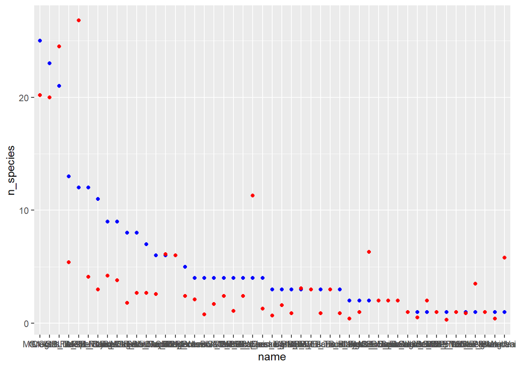

```r
#get locations with the most taxa
top_sites_by_sp <- aggregated_site_data %>%
  arrange(desc(n_species)) %>%
  mutate(name = fct_reorder(BS.site_id, desc(n_species)))

#get species with most sites
top_species_by_site <- aggregated_species_data %>%
  arrange(desc(n_locations)) %>%
  mutate(name = fct_reorder(c(paste(genus, specific_epithet, subspecific)), desc(n_locations)))

top_species_by_site$name <- gsub(" NA", "", top_species_by_site$name)

#plot by site
ggplot(top_sites_by_sp)+
  geom_point(aes(x = name, y = n_species), colour = "blue") +
  geom_point(aes(x = name, y = n_ind/10), colour = "red")
```

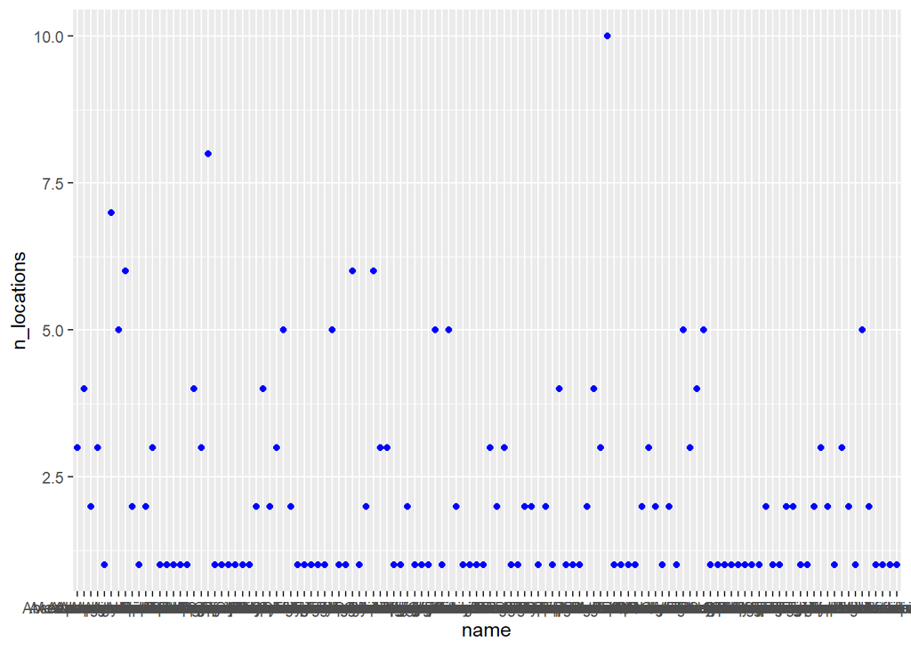

```r
#plot by species
ggplot(top_species_by_site)+
  geom_point(aes(x = name, y = n_locations), colour = "blue")
```

```r
length(top_species_by_site$name)
```

```
## [1] 120
```

```r
nrow(top_species_by_site)
```

```
## [1] 120
```

```r
top_species_by_site$name[1:10]
```

```
##  [1] "Populus tremuloides"                 "Betula populifolia"
##  [3] "Acer rubrum"                         "Acer saccharum"
##  [5] "Fagus grandifolia"                   "Fraxinus americana"
##  [7] "Acer saccharinum"                    "Chamaedaphne calyculata"
##  [9] "Eriophorum vaginatum subsp. spissum" "Juglans cinerea"
```

```r
#the top 6 sites by number of species
top_6_sites <- head(top_sites_by_sp)
top_24_sites <- top_sites_by_sp %>%
  filter(n_species > 3)
top_11_sites <- top_sites_by_sp[1:11,]

#get species lists for top 6 sites
sp_top6_sites <- aggregated_species_data %>%
  melt(id = c(1:6)) %>%
  filter(variable %in% top_6_sites$BS.site_id) %>%
  spread(variable, value) %>%
  mutate(n_top_sites = rowSums(.[7:12])) %>%
  filter(n_top_sites > 0) %>%
  arrange(desc(n_top_sites))

#get species lists for top 24 sites
sp_top24_sites <- aggregated_species_data %>%
  melt(id = c(1:6)) %>%
  filter(variable %in% top_24_sites$BS.site_id) %>%
  spread(variable, value) %>%
  mutate(n_top_sites = rowSums(.[7:30])) %>%
  filter(n_top_sites > 0) %>%
  arrange(desc(n_top_sites, n_ind))

#get species lists for top 11 sites
sp_top11_sites <- aggregated_species_data %>%
  melt(id = c(1:6)) %>%
  filter(variable %in% top_11_sites$BS.site_id) %>%
  spread(variable, value) %>%
  mutate(n_top_sites = rowSums(.[7:17])) %>%
  filter(n_top_sites > 0) %>%
  arrange(desc(n_top_sites))

#get number of species for top sites
nrow(sp_top6_sites)
```

```
## [1] 83
```

```r
nrow(sp_top11_sites)
```

```
## [1] 103
```

```r
nrow(sp_top24_sites)
```

```
## [1] 113
```

```r
#get number of species that are singletons for top sites
nrow(sp_top24_sites[which(sp_top24_sites$n_top_sites == 1),])
```

```
## [1] 59
```

```r
nrow(sp_top11_sites[which(sp_top11_sites$n_top_sites == 1),])
```

```
## [1] 67
```

```r
nrow(sp_top6_sites[which(sp_top6_sites$n_top_sites == 1),])
```

```
## [1] 61
```

```r
#get number of species that are singletons or not for all sites
nrow(aggregated_species_data[which(aggregated_species_data$n_locations == 1),])
```

```
## [1] 62
```

```r
nrow(aggregated_species_data[which(aggregated_species_data$n_locations > 1),])
```

```
## [1] 58
```

```r
nrow(aggregated_species_data)
```

```
## [1] 120
```

```r
#get genera for species found in multiple sites overall
unique(aggregated_species_data$genus[which(aggregated_species_data$n_locations > 1)])
```

```
##  [1] "Abies"        "Acer"         "Agonis"       "Alnus"        "Betula"
##  [6] "Carpinus"     "Carya"        "Celtis"       "Chamaedaphne" "Cirsium"
## [11] "Eriophorum"   "Fagus"        "Frangula"     "Fraxinus"     "Gustavia"
## [16] "Juglans"      "Kalmia"       "Larix"        "Ostrya"       "Phalaris"
## [21] "Phragmites"   "Picea"        "Pinus"        "Populus"      "Prunus"
## [26] "Quercus"      "Rhamnus"      "Rhododendron" "Solidago"     "Sorbus"
## [31] "Spiraea"      "Thuja"        "Tilia"        "Trichilia"    "Tsuga"
## [36] "Typha"        "Ulmus"
```

```r
#get number of species for each genus found in multiple sites overall
unique(aggregated_species_data[which(aggregated_species_data$n_locations > 1),]) %>%
  group_by(genus) %>%
  summarise(n_sp_per_genus = length(unique(specific_epithet))) %>%
  arrange(desc(n_sp_per_genus))
```

```
## # A tibble: 37 x 2
##    genus    n_sp_per_genus
##    <chr>             <int>
##  1 Acer                  7
##  2 Populus               4
##  3 Quercus               4
##  4 Betula                3
##  5 Fraxinus              3
##  6 Carya                 2
##  7 Picea                 2
##  8 Pinus                 2
##  9 Prunus                2
## 10 Ulmus                 2
## # ... with 27 more rows
```

For the top 11 sites, there are 103 species total, with species occurring in maximum of 5/11 sites. 67/103 species are found at only a single of the top 11 sites.

For the purpose of comparing spectra across sites by species, there are 62 singleton species (occurring in only 1 site overall), and 58 species which occur in more than 1 site overall, for a total of 120 species. The species that occur in multiple sites belong to 37 genera, including conifers, Rosids, Asterids and monocots, although there are more rosid species overall (based on skimming list) with most species in the genera Acer, Quercus, and Populus.

```r
#get growth form/habit from flora - not actually included in vascan column - plants$PL.vascan_filter_growth_form

growth_form <- data.frame(species = sort(unique(final_metadata$PL.scientific_name)), growth_form = as.character(NA), stringsAsFactors = FALSE)

#write to edit and enter growth forms from vascan web search (unable to download)
#those from tropics without growth form so far (NA)
#write.csv(growth_form, "./data/tidy/growth_forms.csv", row.names = FALSE)

#read edited growth_form
growth_form_2 <- read.csv("./data/tidy/growth_forms.csv", header = TRUE, stringsAsFactors = FALSE)

#add column for woody/not
growth_form_2$woody <- NA
growth_form_2$woody[which(growth_form_2$growth_form == "Tree" | growth_form_2$growth_form == "Shrub" | growth_form_2$growth_form == "Tree/Shrub")] <- "1"
growth_form_2$woody[which(growth_form_2$growth_form == "Herb")] <- "0"
growth_form_2$woody[which(growth_form_2$growth_form == "Vine")] <- "1"

#spread to get column per growth form type
spreading_habit <-presence_absence(growth_form_2$growth_form)
```

```r
#add those in two categories
spreading_habit$Tree[which(spreading_habit$`Tree/Shrub` == 1)] <- 1
spreading_habit$Shrub[which(spreading_habit$`Tree/Shrub` == 1)] <- 1
#get rid of original column
spreading_habit <- spreading_habit[,-4]

#merge types of growth form objects
growth_form_3 <- cbind(scientific_name = growth_form_2$species, spreading_habit, Woody = growth_form_2$woody)
colnames(growth_form_3)[6] <- "No_info"

#summarize information on growth form
summary_of_growth_forms <- growth_form_3[,-1] %>%  #start with the data frame
  map_dfc(table) %>%  # use map_df from the purrr package to "table" each column
  rownames_to_column("response") %>% #convert the rownames to a column named response
  mutate(resp = case_when(response == 1 ~ "No", #change the resulting 1s to No in resp
                          response == 2 ~ "Yes")) %>%  #change the resulting 2s to Yes in resp
  select(resp, everything(), -response) %>%  #reorder the columns with resp at the front, removing response
  arrange(desc(resp))

write.csv(summary_of_growth_forms, "./data/tidy/summary_growth_form.csv", row.names = FALSE)

#For taxonomy
#retrieve info from vascan
vascan_output <- vascan_search(growth_form$species, format="json", raw = TRUE)

#convert format from json to list
vascan_r <- fromJSON(vascan_output, TRUE, TRUE)

#get family, order, clade from taxize
#to get higher classification eg Order, family and higher clade

taxonomy_table <- data.frame(species = character(121), clade = character(121), class = character(121), order = character(121), family = character(121), stringsAsFactors = FALSE)

#for simplicity, for Magnoliidae, the class is actually the superorder?
#also excluding the tropical plants
for(i in 1:length(vascan_r$results$matches)){
  if (!is.null(vascan_r$results$matches[[i]]) == TRUE & !is.null(vascan_r$results$matches[[i]]$taxonomicAssertions[[1]]$higherClassification) == TRUE){
    higher_class <- vascan_r$results$matches[[i]]$taxonomicAssertions[[1]]$higherClassification
    highest_clade <- str_split(higher_class, ";")[[1]][1]
    if (str_split(higher_class, ";")[[1]][2] == "Magnoliidae"){
      class <- str_split(higher_class, ";")[[1]][3]
      order <- str_split(higher_class, ";")[[1]][4]
      family <- str_split(higher_class, ";")[[1]][5]
    } else if (str_split(higher_class, ";")[[1]][2] == "Pinidae"){
      class <- str_split(higher_class, ";")[[1]][2]
      order <- str_split(higher_class, ";")[[1]][3]
      family <- str_split(higher_class, ";")[[1]][4]
    }
    species <- vascan_r$results$matches[[i]]$taxonomicAssertions[[1]]$acceptedNameUsage
    taxonomy_table$species[i] <- as.character(species)
    taxonomy_table$clade[i] <- highest_clade
    taxonomy_table$class[i] <- class
    taxonomy_table$order[i] <- order
    taxonomy_table$family[i] <- family
  } else {
    taxonomy_table$species[i] <- NA
    taxonomy_table$clade[i] <- NA
    taxonomy_table$class[i] <- NA
    taxonomy_table$order[i] <- NA
    taxonomy_table$family[i] <- NA
  }
  #return(taxonomy_table)
}

#remove empty rows (tropical species)
taxonomy_table_2 <- taxonomy_table %>%
  filter(complete.cases(.))

#save it for later
saveRDS(taxonomy_table_2, "./data/tidy/taxonomy_table_higher_class.rds")
write.csv(taxonomy_table_2, "./data/tidy/taxonomy_table_higher_class.csv", row.names = FALSE)

# #use if need to subdivide query
# vascan_page <- rbind_pages(vascan_r)

#get environmental variables for gps of plants?

summary_of_growth_forms
```

```
## # A tibble: 2 x 7
##   resp  Herb    Shrub   Tree    Vine    No_info Woody
##   <chr> <table> <table> <table> <table> <table> <table>
## 1 Yes   32      26      57        1      15     74
## 2 No    89      95      64      120     106     32
```

```r
#summary of taxonomy
n_per_class <- taxonomy_table_2 %>%
  group_by(class) %>%
  summarize(n = n()) %>%
  arrange(desc(n))
n_per_order <- taxonomy_table_2 %>%
  group_by(order) %>%
  summarize(n = n())%>%
  arrange(desc(n))
n_per_family <- taxonomy_table_2 %>%
  group_by(family) %>%
  summarize(n = n())%>%
  arrange(desc(n))
#how many globally? how many in Canada?
colnames(n_per_order) <- c("group", "CABO")
colnames(n_per_class) <- c("group", "CABO")
CABO <- rbind(n_per_class, n_per_order)

relative_sampling <- data.frame(group = character(25), canada = integer(25), global = integer(25), stringsAsFactors = FALSE)

dir_taxonomy <- list.files("./data/taxonomy", full.names = TRUE)
taxonomy_files <- lapply(dir_taxonomy, read.delim)
for(i in 1:length(taxonomy_files)){
  num_sp <- length(taxonomy_files[which(taxonomy_files[[i]]$Rank == "Species")])
  name <- as.character(taxonomy_files[[i]]$Scientific.name[1])
  relative_sampling$group[i] <- name
  relative_sampling$canada[i] <- num_sp
}

relative_sampling <- merge(relative_sampling, CABO)

relative_sampling <- relative_sampling %>%
  mutate(CABO_canada_pct = round((CABO/canada*100), 2)) %>%
  arrange(desc(CABO_canada_pct))

relative_sampling
```

```
##             group canada global CABO CABO_canada_pct
## 1      Sapindales     33      0   10           30.30
## 2         Pinales     39      0   10           25.64
## 3         Fagales     75      0   17           22.67
## 4         Pinidae     50      0   11           22.00
## 5         Vitales     10      0    1           10.00
## 6     Cupressales     11      0    1            9.09
## 7         Rosales    415      0   17            4.10
## 8         Rosanae   1492      0   57            3.82
## 9        Cornales     28      0    1            3.57
## 10     Dipsacales     69      0    2            2.90
## 11       Malvales     40      0    1            2.50
## 12   Malpighiales    300      0    6            2.00
## 13        Fabales    226      0    4            1.77
## 14        Apiales    116      0    2            1.72
## 15       Ericales    195      0    3            1.54
## 16       Myrtales     82      0    1            1.22
## 17         Poales   1111      0   13            1.17
## 18    Asparagales    178      0    2            1.12
## 19      Asteranae   1727      0   19            1.10
## 20       Lilianae   1463      0   15            1.03
## 21      Asterales    673      0    6            0.89
## 22       Lamiales    393      0    3            0.76
## 23 Caryophyllales    404      0    1            0.25
## 24 Caryophyllanae    404      0    1            0.25
```

```r
write.csv(relative_sampling, "./data/tidy/relative_sampling.csv", row.names = FALSE)
```

Using VASCAN, I resolved species names and retrieved higher order classifications for all species in VASCAN (ie not tropical species). One species was also a synonym (Berberis aquifolium Pursh) so I need to go back and fix that before running VASCAN to get higher classification (or at beginning before any summary stuff).

I still need to get environmental data for plants (if doing that).

There are five classes: Asteranae (19), Caryophyllanae (1), Lilianae (15), Pinidae (11), and Rosanae (57). There are 20 orders (Fagales: 17, Rosales: 17, Poales: 13, Pinales: 10, Sapindales: 10 etc) and 28 families. There is a heavy bias to Rosids overall.

As for how the taxonomic sampling corresponds with Canadian taxonomic diversity, several orders are well represented (eg Sapindales, Fagales, Pinales with 20-30% of species sampled). Others, especially the Asterids, are underrepresented with between 3.5% (Cornales) and 0.75% (Lamiales) species sampled. Monocots are also underrepresented compared to overall taxonomic diversity with 1% of monocots sampled.

```r
#get range of dates and locations by species
aggregated_species_dates <- final_metadata %>%
  group_by(genus, specific_epithet, subspecific) %>%
  summarise(n_ind = n(), earliest_month = min(month_measured), latest_month = max(month_measured), month_range = paste0(min(month_measured), "-", max(month_measured)), duration_sampling = (max(month_measured)-min(month_measured)), n_locations = length(unique(BS.site_id)), across(c(36:84), max)) %>% #, n_species = n(unique(species))
  arrange(desc(duration_sampling))
duration3months <- aggregated_species_dates[which(aggregated_species_dates$duration_sampling > 2),c(1:2,7:8)]

duration2months <- aggregated_species_dates[which(aggregated_species_dates$duration_sampling > 1),c(1:2,7:8)]
```

There are 10 species that were sampled over a three month period or longer. There are 25 species that were sampled over a two month period or longer.

Now, I'll match the spectral data to the updated metadata file (including removing the bad samples above and updating the scientific names).

```r
#combine metadata from spectral data and from metadata files

#make spectral object into dataframe for manipulation
spec_as_df <- as.data.frame(spectral_data, fix_names = "none", metadata = TRUE)

#trim spectra to just those samples in cleaned metadata
spectra_trimmed  <- spec_as_df[which(spec_as_df$sample_id %in% final_metadata$LS.sample_id),]

#add spectra to metadata itself
merged_meta_spectra <- merge(final_metadata, spectra_trimmed, by.x = "LS.sample_id", by.y = "sample_id")
nrow(merged_meta_spectra)
```

```
## [1] 2050
```

```r
#there are some duplicate spectra for the same sample numbers - check this out
nrow(final_metadata) #2046
```

```
## [1] 2046
```

```r
nrow(spectra_trimmed) #2050
```

```
## [1] 2050
```

```r
length(unique(spectra_trimmed$sample_id)) #2046
```

```
## [1] 2046
```

```r
nrow(spec_as_df) #2255
```

```
## [1] 2255
```

```r
dup_spectra <- merged_meta_spectra$LS.sample_id[which(duplicated(merged_meta_spectra$LS.sample_id) == TRUE)]

#spectra numbers and sample numbers are duplicated but the spectra values are different - why?
merged_meta_spectra[which(merged_meta_spectra$LS.sample_id %in% dup_spectra),c(1:5,7,8,13,16,19,20,27,88,91:95)]
```

```
##      LS.sample_id BS.plant_id              LS.project LS.latitude LS.longitude
## 1130     42591114    41393596 2019-Blanchard-MSc-UdeM    45.64307    -73.33395
## 1131     42591114    41393596 2019-Blanchard-MSc-UdeM    45.64307    -73.33395
## 1135     42594368    41388983 2019-Blanchard-MSc-UdeM    45.64307    -73.33396
## 1136     42594368    41388983 2019-Blanchard-MSc-UdeM    45.64307    -73.33396
## 1137     42594718    41391716 2019-Blanchard-MSc-UdeM    45.64307    -73.33396
## 1138     42594718    41391716 2019-Blanchard-MSc-UdeM    45.64307    -73.33396
## 1794     46498048    40702775       2019-CABO-General    45.98866    -74.00591
## 1795     46498048    40702775       2019-CABO-General    45.98866    -74.00591
##                                    LS.scientific_name LS.date_measured
## 1130                          Prunus serotina Ehrhart       2019-06-28
## 1131                          Prunus serotina Ehrhart       2019-06-28
## 1135                          Prunus serotina Ehrhart       2019-06-28
## 1136                          Prunus serotina Ehrhart       2019-06-28
## 1137                          Prunus serotina Ehrhart       2019-06-28
```

[output cut: 30 more lines]

```r
#make spectra back into spectral object
trimmed_as_spectra <- as_spectra(spectra_trimmed, name_idx = 1, meta_idxs = c(2:4))


#write spectral object as rds (trimmed simple spectra) and dataframe of spectra merged with metadata as csv

saveRDS(trimmed_as_spectra, "./data/tidy/trimmed_spectra_by_meta.rds")
write.csv(merged_meta_spectra, "./data/tidy/merged_meta_spectra_trimmed.csv", row.names = FALSE)


#get list of all species for phylogeny
species_all <- aggregated_species_data %>%
  unite(species_names, genus, specific_epithet, subspecific, sep = "_", na.rm = TRUE) %>%
  select(species_names)

write.csv(species_all, "./data/tidy/species_names_for_phylo.csv", row.names = FALSE)
```

I need to figure out why those eight (four numbers) spectra are duplicated.